# Psychoinformatics - Week 4 (Exercises)

by 張瑋宸 (b08207003@ntu.edu.tw)

## 1 Analyze what videos go viral? (8 points)

Please use [YouTube APIs](https://developers.google.com/youtube/v3/code_samples/python) to carry out a data-driven or hypothesis-driven microstudy about the characteristics of viral videos.

You need to present, here in this notebook, AT LEAST two **statistical** figures or tables as supporting evidence for your arguments. Each of these figures/tables deserves 4 points.

## 介紹

本次分析打算以data-driven的方式，收集到在時間點(2021/10/24 17:00左右)台灣地區的youtube熱門影片前50名資料。藉由分析其中的內容、類別及各種統計數據，再從結果歸納出熱門影片可能有什麼特性。 而在分析所選用的變數中，個人比較有興趣的為以下:

1. 影片點閱率、讚數、留言數等等。以這些基本統計數據和熱門影片的排行做相關，看其中的關聯性。
2. 影片時長(duration)。猜想是否影片長度比較短的影片，是否會因為較容易看完而有比較多的點閱率，因此上熱門。
3. 影片分類，藉youtube本身替影片的分類(categoryId)，從中歸納熱門影片的的類型。

以下會先從研究方法收集到的資料開始介紹，接下來從上述三方面逐個分析，最後再做個總結與討論研究的可能改進之處。

## 研究方法與資料收集

首先先取得youtube data api和key收集資料。本次抓取的資料來源是youtube，以台灣地區在2021/10/24 17:00左右時間點，收集前五十名的熱門影片進行分析。

```python
#Install packages
!pip install oauth2 google-api-python-client
!pip install --upgrade oauth2clien
```

```
ERROR: Could not find a version that satisfies the requirement oauth2clien
ERROR: No matching distribution found for oauth2clien
```

```python
DEVELOPER_KEY = "AIzaSyC26Zn_5O3Egr9mC5c5HWZF1-vqTuoCEqs" #Load API key
```

```python
from apiclient.discovery import build

youtube = build('youtube', 'v3', developerKey=DEVELOPER_KEY)
result = youtube.videos().list(
    part='snippet,contentDetails,statistics',
    chart='mostPopular',
    regionCode='TW',maxResults=50).execute() #To get the popular Videos' data

#most informations about the video is stored under the key 'items'
video = result['items']
```

把抓到的資料整理成dataframe

```python
import pandas as pd
import numpy as np

#create a list to contain many dict.
stats  = []


for i in range(50):
 content = video[i]['snippet']  #dict
 details = video[i]['contentDetails']  #dict (duration time is included in here)
 info = video[i]['statistics'] #view count etc. also dict
 content.update(info)
 content.update(details)
 stats.append(content)


df = pd.DataFrame(stats, index = list(range(1,51))) #index represent rankings
df.head()
```

|  | publishedAt | channelId | title | description | thumbnails | channelTitle | tags | categoryId | liveBroadcastContent | localized | ... | commentCount | duration | dimension | definition | caption | licensedContent | contentRating | projection | defaultLanguage | regionRestriction |
| --- | --- | --- | --- | --- | --- | --- | --- | --- | --- | --- | --- | --- | --- | --- | --- | --- | --- | --- | --- | --- | --- |
| 1 | 2021-10-23T12:07:35Z | UCpu3bemTQwAU8PqM4kJdoEQ | 【盧秀芳辣晚報】3Q團隊喊"出狀況去監票" 狼來了? 刪Q成功 3Q:還有7天立委可做! 恐... | #中天辣晚報 #盧秀芳 #陳柏惟 #刪Q #顏寬恒 #投票 #民進黨 #國民黨 #混打 #立... | {'default': {'url': 'https://i.ytimg.com/vi/7t... | 中天新聞 | [中天新聞直播, 監督的力量, 主播出任務, Cti Talk, 熱搜發燒榜, 中天電視, ... | 25 | none | {'title': '【盧秀芳辣晚報】3Q團隊喊"出狀況去監票" 狼來了? 刪Q成功 3Q:... | ... | 544 | PT2H31S | 2d | hd | false | True | {} | rectangular | NaN | NaN |
| 2 | 2021-10-23T10:20:03Z | UCpu3bemTQwAU8PqM4kJdoEQ | 【刪Q特報#LIVE】罷免陳柏惟開票直播特別報導 @中天新聞 20211023 | #刪Q投票#陳柏惟#罷Q#罷免陳柏惟\n\n📢📢📢【全球大視野】頻道開會員囉!!!!!!!!... | {'default': {'url': 'https://i.ytimg.com/vi/DG... | 中天新聞 | [中天新聞直播, 中天新聞, 政治, 監督的力量, 主播出任務, Cti Talk, 熱搜發... | 25 | none | {'title': '【刪Q特報#LIVE】罷免陳柏惟開票直播特別報導 @中天新聞 202... | ... | 229 | PT3H41S | 2d | hd | false | True | {} | rectangular | NaN | NaN |
| 3 | 2021-10-23T10:48:23Z | UC5l1Yto5oOIgRXlI4p4VKbw | 【中天互動LIVE】"罷免陳柏惟" 就看今天 刪Q總部 "開票全記錄" 中天新聞現場直擊... | #罷免#刪Q#陳柏惟#開票\n\n📢📢📢【全球大視野】頻道開會員囉!!!!!!!!\nhtt... | {'default': {'url': 'https://i.ytimg.com/vi/NK... | 中天電視 | [中天, 中天電視, 中天新聞, CTI, 會員] | 25 | none | {'title': '【中天互動LIVE】"罷免陳柏惟" 就看今天 刪Q總部 "開票全記錄... | ... | 241 | PT2H29M40S | 2d | hd | false | True | {} | rectangular | NaN | NaN |
| 4 | 2021-10-23T12:23:57Z | UCLZBXiS9ZrIXgKBs_SMfGBQ | 【完整版上集】史上第一次! 成功罷免現任立委 "芒果乾"也救不了陳柏惟? TVBS戰情室 2... | 本錄影遵守防疫規範，所有人員皆經量體溫、消毒，並全程配戴口罩。\n\n✔訂閱【少康戰情室】h... | {'default': {'url': 'https://i.ytimg.com/vi/J2... | 少康戰情室 | [少康戰情室, 少康, 習近平, 习近平, XiJinping, 大陸, 中國, 中国, 少... | 25 | none | {'title': '【完整版上集】史上第一次! 成功罷免現任立委 "芒果乾"也救不了陳柏惟... | ... | 1846 | PT27M28S | 2d | hd | false | True | {} | rectangular | zh-TW | {'blocked': ['MY']} |
| 5 | 2021-10-15T10:00:12Z | UCFUtqTcgJgRnmZ3tMU6P74Q | 聽見玻璃心碎的聲音... 黃明志 Ft.陳芳語【玻璃心】@鬼才做音樂 2021 Ghosician | 這是一首充滿了粉紅色的浪漫甜蜜情歌，請玻璃心患者慎入... 也請大家關注黃明志最新剛剛開的微... | {'default': {'url': 'https://i.ytimg.com/vi/-R... | Namewee | [玻璃心, fragile, 小粉紅, Kimberley Chen, 陳芳語, Kimbe... | 10 | none | {'title': '聽見玻璃心碎的聲音... 黃明志 Ft.陳芳語【玻璃心】@鬼才做音樂 ... | ... | 132386 | PT4M55S | 2d | hd | true | True | {} | rectangular | zh-TW | NaN |

5 rows × 25 columns

## 結果分析

如在介紹所寫，本部分會先從影片基本統計數據開始分析，再分析影片時間，最後分析影片類型。

### 分析基本影片統計數據

首先，因為在df中存的資料型態為字串，必須先轉成數字才能計算。另外因為影片間的同個統計數據差異很大，因此做log transformation，以方便在Scatter plot中看出相關。 然後把這些轉換過的數據存進新的dataframe(df3)。

```python
df3 = pd.DataFrame(index = list(range(1,51)) )
df3['rank'] = list(range(1,51)) #or use np.arange(1,51)
df3['LogViewCount'] = np.log10(pd.to_numeric(df['viewCount'])) #transform str to int
df3['LogLikeCount'] = np.log10(pd.to_numeric(df['likeCount'])) #log transformastion because of data scale
df3['LogDislikeCount'] = np.log10(pd.to_numeric(df['dislikeCount']))
#在觀看數比較多的影片，likeCount, dislikeCount理論上也比較多，因此計算兩者odds ratio
df3['LogLikeDislikeRatio'] = np.log10(pd.to_numeric(df['likeCount'])/pd.to_numeric(df['dislikeCount']))
df3['LogCommentCount'] = np.log10(pd.to_numeric(df['commentCount']))

df3 = df3.replace(-np.inf, 0)
##Some videos have no comment (might be closed), the log-transformed values would be -inf,
  ##then the scatter plot can't be drawn.

#Morever, we can draw a regression fitting line, but it doesn't really matter.
```

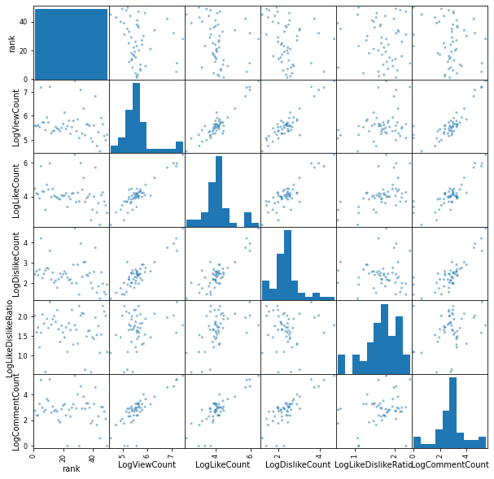

```python
import matplotlib.pyplot as plt
plt.rcParams['figure.figsize']=[10,10] #size of the plot(inches)
pd.plotting.scatter_matrix(df3);
```

由這些散布圖可以簡單看到這些基本的統計數據本身都有正相關。除了like dislike的odds ratio似乎和其他指標相比比較看不到關係。

除了基本統計數據本身的關係外，更重要的是在發燒影片的排名和數據的相關如何? 上圖並未看出相關現象，可能是因為排名本身是ranked data。因此接下來計算Spearman相關係數，看看彼此之間有沒有關係。

```python
#I want to know the if rank correlated with some of these stats.
df3.corr(method = 'spearman')
```

|  | rank | LogViewCount | LogLikeCount | LogDislikeCount | LogLikeDislikeRatio | LogCommentCount |
| --- | --- | --- | --- | --- | --- | --- |
| rank | 1.000000 | -0.309100 | -0.381993 | -0.361401 | -0.111068 | -0.145179 |
| LogViewCount | -0.309100 | 1.000000 | 0.790252 | 0.735240 | 0.184538 | 0.804322 |
| LogLikeCount | -0.381993 | 0.790252 | 1.000000 | 0.677519 | 0.504346 | 0.742850 |
| LogDislikeCount | -0.361401 | 0.735240 | 0.677519 | 1.000000 | -0.148431 | 0.745846 |
| LogLikeDislikeRatio | -0.111068 | 0.184538 | 0.504346 | -0.148431 | 1.000000 | 0.183744 |
| LogCommentCount | -0.145179 | 0.804322 | 0.742850 | 0.745846 | 0.183744 | 1.000000 |

相關矩陣中第一格column顯示排名(rank)和觀看數(viewCount)、喜歡數(likeCount)、不喜歡數(dislikeCount)都有中程度相關，不過與ratio和留言數兩者上相關就很微弱。相關係數為負數因為排名較前面的分派到比較小的數字，排名較前(rank較小)的在這些統計數據上反而會比較大。另外，還可以看見ratio和觀看數之間的相關較小，這使得ratio比起喜歡數和不喜歡數以及留言數，更適合作為獨立的變項與排名比較。

因此對於熱門影片的排行，觀看數與其有一定的相關，但喜歡不喜歡的ratio、留言數與排名並無太大相關。

### 分析影片長度

df['duration'] 中存的值是"iso 8601 string"，需要轉換過才能進一步分析。

```python
#Transform "iso 8601 string" into seconds(int).

import datetime

def get_isosplit(s, split):
    if split in s:
        n, s = s.split(split)
    else:
        n = 0
    return n, s

def parse_isoduration(s):

    # Remove prefix
    s = s.split('P')[-1]

    # Step through letter dividers
    days, s = get_isosplit(s, 'D')
    _, s = get_isosplit(s, 'T')
    hours, s = get_isosplit(s, 'H')
    minutes, s = get_isosplit(s, 'M')
    seconds, s = get_isosplit(s, 'S')

    # Convert all to seconds
    dt = datetime.timedelta(days=int(days), hours=int(hours), minutes=int(minutes), seconds=int(seconds))
    return int(dt.total_seconds())
```

轉換數據存進dataframe中，並且做簡單的描述統計、畫直方圖。

```python
#Transform data in df['duration'] into minutes. Store data in df3['durMin']
durMin = [] #list
for i in np.arange(1,51):
  durMin.append(parse_isoduration(df['duration'][i])/60)
df['durMin'] = durMin #df has many qualitative data, we could fit the data with corresponding video
df3['durMin'] = durInMin #df3 has 'rank', we could show the corr. between ranks and durations

df3['durMin'].describe()
```

```
count     50.000000
mean      69.795000
std      117.200566
min        2.616667
25%        5.754167
50%       13.641667
75%      118.825000
max      715.000000
Name: durMin, dtype: float64
```

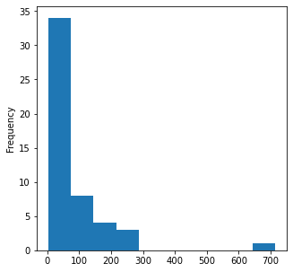

```python
plt.rcParams['figure.figsize']=[5,5]
df3['durMin'].plot.hist();
```

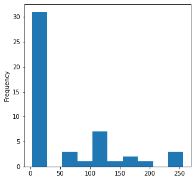

```python
#drop outlier
df3.nsmallest(49, 'durMin')['durMin'].plot.hist();
```

同時也稍微看了一下這個715分鐘的影片到底是何方神聖，結果如下。

```python
#To see who's the outlier
df.nlargest(1, 'durMin')
```

|  | publishedAt | channelId | title | description | thumbnails | channelTitle | tags | categoryId | liveBroadcastContent | localized | ... | dimension | definition | caption | licensedContent | contentRating | projection | defaultLanguage | regionRestriction | durInMin | durMin |
| --- | --- | --- | --- | --- | --- | --- | --- | --- | --- | --- | --- | --- | --- | --- | --- | --- | --- | --- | --- | --- | --- |
| 45 | 2021-10-23T17:31:32Z | UCiBfeXK4qw9QAqx92RErhxA | #抖音神曲2021 %抖音流行歌曲 2021 TIK TOK抖音音樂熱門歌單 \ 2021四... | #抖音神曲2021 %抖音流行歌曲 2021 TIK TOK抖音音樂熱門歌單 \ 2021四... | {'default': {'url': 'https://i.ytimg.com/vi/lJ... | Jean Huang | [抖音神曲2021, 抖音, 十一月, 抖音合集, 十一月热门歌曲, 洗脑抖音歌曲, TIK... | 10 | none | {'title': '#抖音神曲2021 %抖音流行歌曲 2021 TIK TOK抖音音樂熱... | ... | 2d | hd | false | True | {} | rectangular | NaN | NaN | 715.0 | 715.0 |

1 rows × 27 columns

除了簡單的描述統計，也抓出基本統計數據和影片長度做相關矩陣，以及用spearman相關係數計算影片長度和熱門排名之間的關係。

```python
#df4 is just df3 without log transformation
df4 = pd.DataFrame(index = np.arange(1,51))

df4['ViewCount'] = pd.to_numeric(df['viewCount']) #transform str to int
df4['LikeCount'] = pd.to_numeric(df['likeCount'])
df4['DislikeCount'] = pd.to_numeric(df['dislikeCount'])
df4['LikeDislikeRatio'] = (pd.to_numeric(df['likeCount'])/pd.to_numeric(df['dislikeCount']))
df4['CommentCount'] = pd.to_numeric(df['commentCount'])
df4['durMin'] = durMin

#correlation between duration time and some statistics
df4.corr(method = 'pearson')
```

|  | ViewCount | LikeCount | DislikeCount | LikeDislikeRatio | CommentCount | durMin |
| --- | --- | --- | --- | --- | --- | --- |
| ViewCount | 1.000000 | 0.950777 | 0.896403 | 0.208171 | 0.975127 | -0.181965 |
| LikeCount | 0.950777 | 1.000000 | 0.961409 | 0.151775 | 0.947577 | -0.151884 |
| DislikeCount | 0.896403 | 0.961409 | 1.000000 | 0.009432 | 0.922354 | -0.133151 |
| LikeDislikeRatio | 0.208171 | 0.151775 | 0.009432 | 1.000000 | 0.174620 | -0.271554 |
| CommentCount | 0.975127 | 0.947577 | 0.922354 | 0.174620 | 1.000000 | -0.160709 |
| durMin | -0.181965 | -0.151884 | -0.133151 | -0.271554 | -0.160709 | 1.000000 |

```python
df4['rank'] = np.arange(1,51)
df4.corr( method = 'spearman')
```

|  | ViewCount | LikeCount | DislikeCount | LikeDislikeRatio | CommentCount | durMin | rank |
| --- | --- | --- | --- | --- | --- | --- | --- |
| ViewCount | 1.000000 | 0.790252 | 0.735240 | 0.184538 | 0.804322 | -0.324274 | -0.309100 |
| LikeCount | 0.790252 | 1.000000 | 0.677519 | 0.504346 | 0.742850 | -0.204226 | -0.381993 |
| DislikeCount | 0.735240 | 0.677519 | 1.000000 | -0.148431 | 0.745846 | -0.168792 | -0.361401 |
| LikeDislikeRatio | 0.184538 | 0.504346 | -0.148431 | 1.000000 | 0.183744 | -0.236591 | -0.111068 |
| CommentCount | 0.804322 | 0.742850 | 0.745846 | 0.183744 | 1.000000 | -0.462529 | -0.145179 |
| durMin | -0.324274 | -0.204226 | -0.168792 | -0.236591 | -0.462529 | 1.000000 | -0.344826 |
| rank | -0.309100 | -0.381993 | -0.361401 | -0.111068 | -0.145179 | -0.344826 | 1.000000 |

在影片長度與各種基本統計數據的pearson相關矩陣中，發現彼此之間呈現負相關，與前頭猜測比較短的影片會有比較高的觀看數相符。不過這些相關係數除了like/Dislike ratio外，相關都不超過.2，並不是很大。  
而在長度與排行之間的spearman相關係數約為-.345，這個負相關表示影片越長，在熱門50影片的排名就越前面，和原先的猜想有所不同。

### Analysing the categories of the videos (categoryId)

存在影片中的categoryId似乎為youtube自己替影片分類的類別，比起在影片中可以由上傳者自己編輯的tag，似乎是個比較穩定的數據。這裡的將藉由這個分類方式將前50名熱門影片分類，看哪種類型的影片上了熱門。

```python
df['categoryId'].head()
```

```
1    25
2    25
3    25
4    25
5    10
Name: categoryId, dtype: object
```

由上面這個測試可以發現categoryId裡面都存數字，而非真正的影片類型。必須先抓取到Id和類型之間的對照表，才能知道每部影片的分類是什麼。  
從以下網址參考，可以抓到台灣地區的categoryId與實際類型對應表。  
https://developers.google.com/youtube/v3/docs/videoCategories/list?apix_params=%7B%22regionCode%22%3A%22TW%22%7D

```python
request = youtube.videoCategories().list(
    part='snippet',
    regionCode='TW')
catId = request.execute()

#catId['items']
```

```python
IdList = []
for i in np.arange(len(catId['items'])):
    category= {'categoryId':catId['items'][i]['id'],
               'category':catId['items'][i]['snippet']['title']}
    IdList.append(category)
Id_df = pd.DataFrame(IdList)
```

將抓到的category Id與實際影片類型的對照表合併到df(包含熱門前50的dataframe)，並以類型做分類繪製bar plot。 看在熱門影片中每種類型各佔多少。

```python
temp = df.merge(Id_df)
categories = temp.groupby(['category']).size()
categories
```

```
category
Comedy               1
Education            1
Entertainment        9
Film & Animation     2
Gaming               2
Music                8
News & Politics     21
People & Blogs       5
Pets & Animals       1
dtype: int64
```

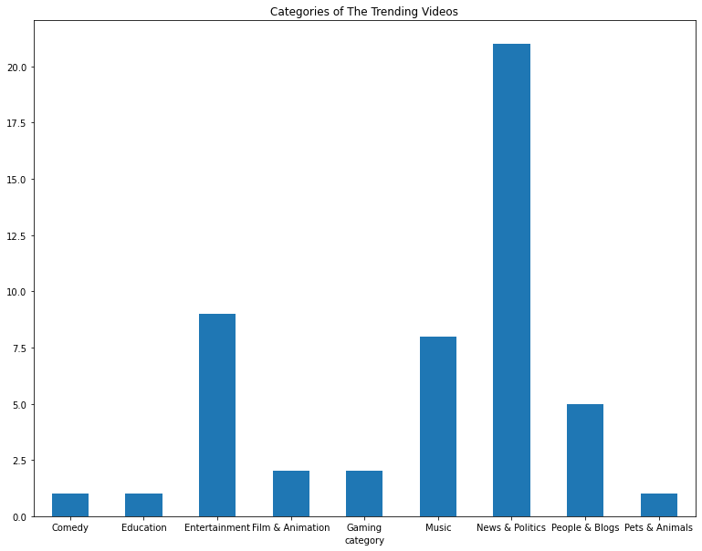

```python
plt.rcParams['figure.figsize']=[13,10]
categories.plot.bar(rot = 0, title = 'Categories of The Trending Videos');
```

由此可見台灣此時的前五十名發燒影片的類型分布，新聞與政治數量最多，佔了將近一半；其次為娛樂，音樂和人物與部落格緊接在後。新聞與政治的高比例可能和昨天(10/23)有罷免選舉有關，反映出本時間點的熱門話題。

## 討論

本次分析只挑選單一時間點的50部熱門影片，樣本數和代表性本身都有些不足。只有抓取熱門影片，並未去找尋其他「非熱門」的影片做為比較，讓本次討論比較像是「分析熱門影片的影片特性」，而非「分析什麼影片才會上熱門」。只選取單一時間點做分析，在上述影片類型的分析上，有可能被當下事件所影響，造成推論的偏誤，如:因為發生社會重大事件使得熱門影片的「新聞」類型上升。

未來可以嘗試去抓取不同時間點的熱門影片排行納入分析；此外也能夠去挑選非熱門的影片和熱門影片作比較，在歸納資訊上或許會有比較好的結果。

### Please submit this file to NTU COOL before next Monday (10/25).